# project1

Peiyu Chen

2024-09-07

## check package and data

```r
## Install the tidyverse package if you don't have it
if (!require("tidyverse", quietly = TRUE)) {
    install.packages("tidyverse")
}

## Install the remotes package if you don't have it
if (!require("remotes", quietly = TRUE)) {
    install.packages("remotes")
}
## Install the tidytuesdayR package (from GitHub) if you don't have it
if (!require("tidytuesdayR", quietly = TRUE)) {
    remotes::install_github("dslc-io/tidytuesdayR")
}

##to aviod redownloading data:

library("here")
library("tidyverse")

# tests if a directory named "data" exists locally
if (!dir.exists(here("data"))) {
  dir.create(here("data"))
}

# saves data only once (not each time you knit a R Markdown)
if (!file.exists(here("data", "chocolate.RDS"))) {
  url_csv <- "https://raw.githubusercontent.com/rfordatascience/tidytuesday/master/data/2022/2022-01-18/chocolate.csv"
  chocolate <- readr::read_csv(url_csv)

  saveRDS(chocolate, file = here("data", "chocolate.RDS"))
}

chocolate <- readRDS(here("data", "chocolate.RDS"))
as_tibble(chocolate)
```

```
## # A tibble: 2,530 × 10
##      ref company_manufacturer company_location review_date
##    <dbl> <chr>                <chr>                  <dbl>
##  1  2454 5150                 U.S.A.                  2019
##  2  2458 5150                 U.S.A.                  2019
##  3  2454 5150                 U.S.A.                  2019
##  4  2542 5150                 U.S.A.                  2021
##  5  2546 5150                 U.S.A.                  2021
##  6  2546 5150                 U.S.A.                  2021
##  7  2542 5150                 U.S.A.                  2021
##  8   797 A. Morin             France                  2012
##  9   797 A. Morin             France                  2012
## 10  1011 A. Morin             France                  2013
## # ℹ 2,520 more rows
## # ℹ 6 more variables: country_of_bean_origin <chr>,
## #   specific_bean_origin_or_bar_name <chr>, cocoa_percent <chr>,
## #   ingredients <chr>, most_memorable_characteristics <chr>, rating <dbl>
```

```r
glimpse(chocolate)
```

```
## Rows: 2,530
## Columns: 10
## $ ref                              <dbl> 2454, 2458, 2454, 2542, 2546, 2546, 2…
## $ company_manufacturer             <chr> "5150", "5150", "5150", "5150", "5150…
## $ company_location                 <chr> "U.S.A.", "U.S.A.", "U.S.A.", "U.S.A.…
## $ review_date                      <dbl> 2019, 2019, 2019, 2021, 2021, 2021, 2…
## $ country_of_bean_origin           <chr> "Tanzania", "Dominican Republic", "Ma…
## $ specific_bean_origin_or_bar_name <chr> "Kokoa Kamili, batch 1", "Zorzal, bat…
## $ cocoa_percent                    <chr> "76%", "76%", "76%", "68%", "72%", "8…
## $ ingredients                      <chr> "3- B,S,C", "3- B,S,C", "3- B,S,C", "…
## $ most_memorable_characteristics   <chr> "rich cocoa, fatty, bready", "cocoa, …
## $ rating                           <dbl> 3.25, 3.50, 3.75, 3.00, 3.00, 3.25, 3…
```

## Part 1: Explore data

1. Make a histogram of the rating scores to visualize the overall distribution scores. Change the number of bins from default to 10, 15, 20, and 25. Pick on the one that you think looks the best.Explain what the difference is when you changes the number of bins and explain why you picked the one you did.

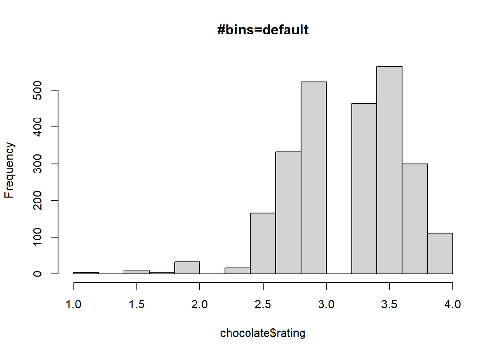

```r
hist(chocolate$rating, main = "#bins=default")
```

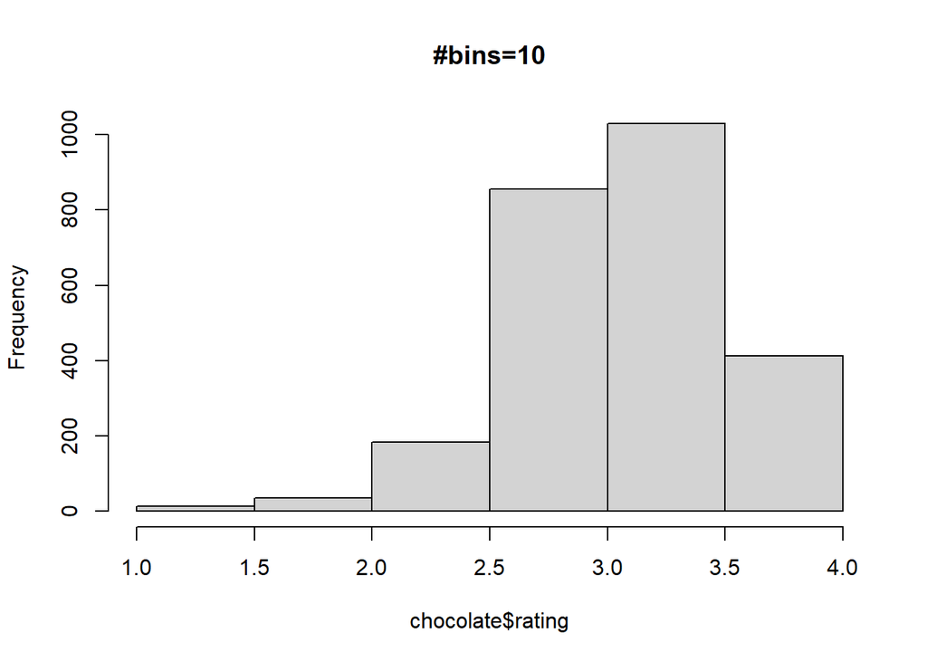

```r
hist(chocolate$rating, breaks=10, main = "#bins=10")
```

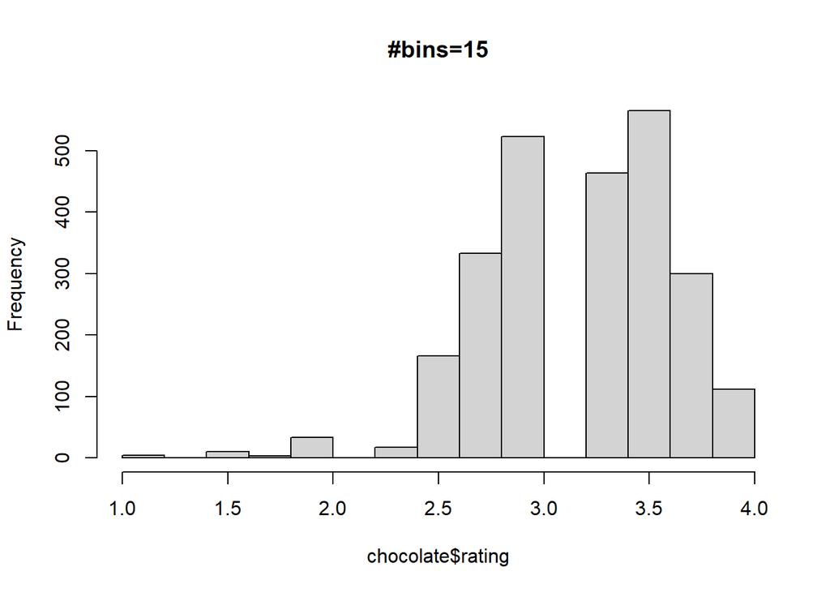

```r
hist(chocolate$rating, breaks=15, main = "#bins=15")
```

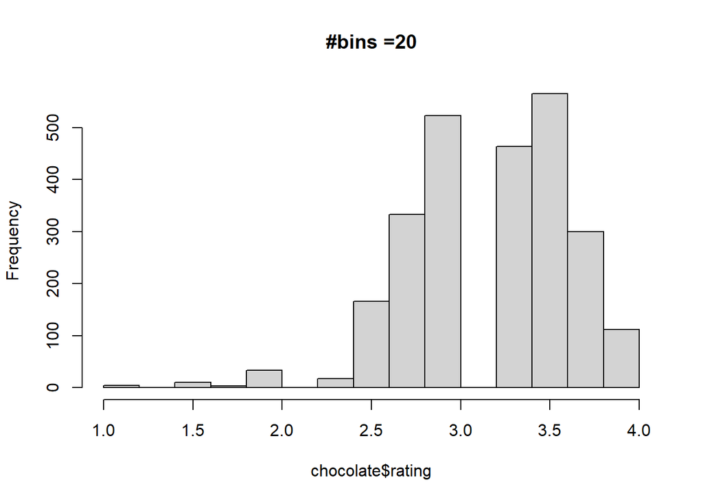

```r
hist(chocolate$rating, breaks=20, main = "#bins =20")
```

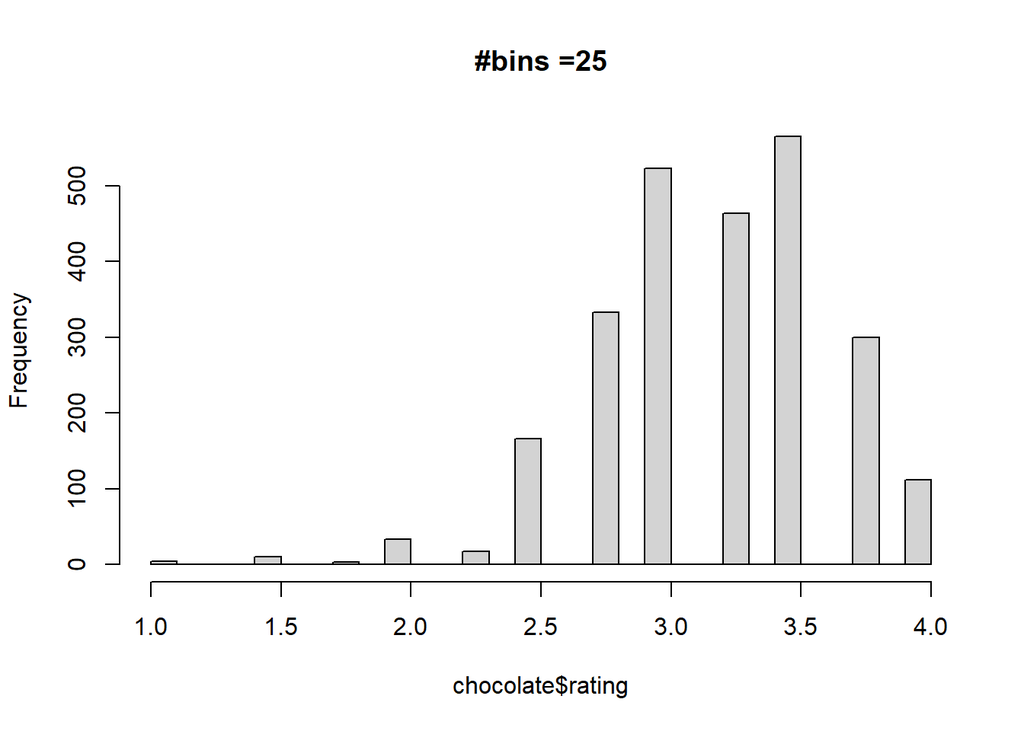

```r
hist(chocolate$rating, breaks=25, main = "#bins =25")
```

2. Consider the countries where the beans originated from. How many reviews come from each country of bean origin?

```r
beans <- dplyr::filter(chocolate, company_location == country_of_bean_origin)
count(dplyr::group_by(beans,country_of_bean_origin))
```

```
## # A tibble: 31 × 2
## # Groups:   country_of_bean_origin [31]
##    country_of_bean_origin     n
##    <chr>                  <int>
##  1 Australia                  3
##  2 Bolivia                    2
##  3 Brazil                    24
##  4 Colombia                  26
##  5 Costa Rica                 8
##  6 Dominican Republic        11
##  7 Ecuador                   56
##  8 El Salvador                3
##  9 Fiji                       4
## 10 Ghana                      1
## # ℹ 21 more rows
```

3. What is average rating scores from reviews of chocolate bars that have Ecuador as country_of_bean_origin in this dataset?

For this same set of reviews, also calculate

1. the total number of reviews and
2. the standard deviation of the rating scores.

Your answer should be a new data frame with these three summary statistics in three columns. Label the name of these columns mean, sd, and total.

```r
ecuador <- chocolate %>%
  dplyr::group_by(country_of_bean_origin)%>%
  dplyr::filter(country_of_bean_origin == "Ecuador")

summary <- ecuador %>%
  dplyr::summarise (
    mean = mean(rating),
    sd = sd(rating),
    total = n()
  )
print(summary)
```

```
## # A tibble: 1 × 4
##   country_of_bean_origin  mean    sd total
##   <chr>                  <dbl> <dbl> <int>
## 1 Ecuador                 3.16 0.512   219
```

4. Which company location makes the best chocolate (or has the highest ratings on average) with beans from Ecuador?

```r
maxecuador <- ecuador %>%
  dplyr::group_by(company_location)%>%
  dplyr::summarise(mean= mean(rating)) %>%
  arrange(desc(mean))%>%
  slice(1)
print(maxecuador)
```

```
## # A tibble: 1 × 2
##   company_location  mean
##   <chr>            <dbl>
## 1 Australia         3.81
```

5. Calculate the average rating across all country of origins for beans. Which top 3 countries (for bean origin) have the highest ratings on average?

   Solution: the top three countries are Tobago, China, and Sao Tome & Principe.

```r
high3 <- chocolate %>% dplyr::group_by(country_of_bean_origin) %>%
  dplyr::summarise(mean=mean(rating))%>%
  arrange(desc(mean))%>%
  slice(1:3)
print(high3)
```

```
## # A tibble: 3 × 2
##   country_of_bean_origin  mean
##   <chr>                  <dbl>
## 1 Tobago                  3.62
## 2 China                   3.5
## 3 Sao Tome & Principe     3.5
```

6. Following up on the previous problem, now remove any countries of bean origins that have less than 10 chocolate bar reviews. Now, which top 3 countries have the highest ratings on average?

   Solution: The top three countries are Solomon Islands, Congo, and Cuba.

```r
high3_10 <- chocolate %>% group_by(country_of_bean_origin) %>%
  dplyr::filter(n() >=10)%>%
  dplyr::summarise(mean=mean(rating))%>%
  arrange(desc(mean))%>%
  slice(1:3)

print(high3_10)
```

```
## # A tibble: 3 × 2
##   country_of_bean_origin  mean
##   <chr>                  <dbl>
## 1 Solomon Islands         3.45
## 2 Congo                   3.32
## 3 Cuba                    3.29
```

7. For this last part, let’s explore the relationship between percent chocolate and ratings.

Use the functions in dplyr, tidyr, and lubridate to perform the following steps to the chocolate dataset:

```
a. Identify the countries of bean origin with at least 50 reviews. Remove reviews from countries are not in this list.

b. Using the variable describing the chocolate percentage for each review, create a new column that groups chocolate percentages into one of four groups: (i) <60%, (ii) >=60 to <70%, (iii) >=70 to <90%, and (iii) >=90%
(Hint: check out the substr() function in base R and the case_when() function from dplyr – see example below).

c. Using the new column described in #2, re-order the factor levels (if needed) to be starting with the smallest percentage group and increasing to the largest percentage group (Hint check out the fct_relevel() function from forcats).

d. For each country, make a set of four side-by-side boxplots plotting the groups on the x-axis and the ratings on the y-axis. These plots should be faceted by country.
```

On average, which category of chocolate percentage is most highly rated? Do these countries mostly agree or are there disagreements?

```
  Answer: In the overall boxplot, the second cocoa percentage group, of which the range between 60% to 70%, and the third cocoa percentage group, of which the range between 70% to 90%, have the highest median of rating scores. And most of the countries agree with the overall patterns.
```

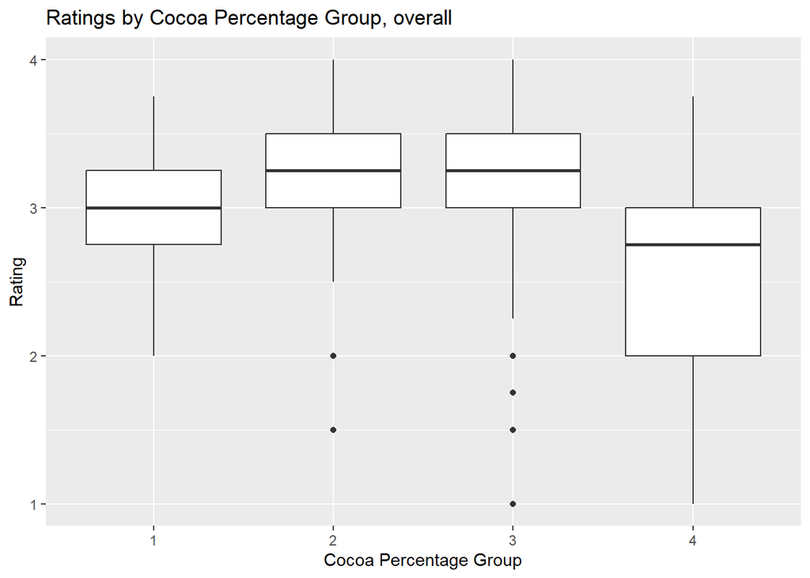

```r
library(dplyr)
library(tidyr)
library(lubridate)
library(ggplot2)

#a. identify countries have more than 50 reviews.
country50 <- chocolate %>%
  dplyr::group_by(country_of_bean_origin) %>%
  dplyr::mutate(review_n = n()
  )%>%
  dplyr::filter(review_n >= 50)

#b. create new variable- 4 groups: (i) <60%, (ii) >=60 to <70%, (iii) >=70 to <90%, and (iii) >=90%
country50$cocoa_num <- as.numeric(substr(country50$cocoa_percent, 1, nchar(country50$cocoa_percent)-1))

country50 <- country50 %>% dplyr::mutate(percgroup = case_when(
        cocoa_num < 60 ~ 1,
        cocoa_num >= 60 & cocoa_num <70 ~ 2,
        cocoa_num >= 70 & cocoa_num <90 ~ 3,
        cocoa_num >=90 ~ 4
    ))



ggplot(country50 , aes(x = as.factor (percgroup), y = rating)) +
  geom_boxplot() +
  labs(x = "Cocoa Percentage Group",
       y = "Rating",
       title = "Ratings by Cocoa Percentage Group, overall")
```

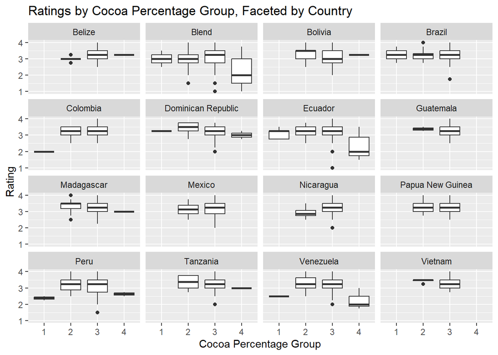

```r
 ggplot(country50 , aes(x = as.factor (percgroup), y = rating)) +
  geom_boxplot() +
  facet_wrap(~ country_of_bean_origin) +
  labs(x = "Cocoa Percentage Group",
       y = "Rating",
       title = "Ratings by Cocoa Percentage Group, Faceted by Country")
```

## Part 2: Joint dataset together

Tasks

1. Use this dataset it to create a new column called continent in our chocolate dataset1 that contains the continent name for each review where the country of bean origin is.
2. Only keep reviews that have reviews from countries of bean origin with at least 10 reviews.
3. Also, remove the country of bean origin named “Blend”.
4. Make a set of violin plots with ratings on the y-axis and continents on the x-axis.

```r
library(gapminder)
#view(gapminder)
gapminder1 <- gapminder %>%
  dplyr::group_by(country)%>%
  distinct(country, continent)



newchocol <- chocolate %>%
  left_join(gapminder1, by = c("country_of_bean_origin" = "country")) %>%
  dplyr::group_by(country_of_bean_origin) %>%
  dplyr::mutate(
    continent = case_when(
      country_of_bean_origin == "Fiji"| country_of_bean_origin == "Papua New Guinea"| country_of_bean_origin== "Vanuatu"|country_of_bean_origin == "Solomon Islands" ~ "Oceania",
      country_of_bean_origin == "Sao Tome"| country_of_bean_origin == "Congo" ~ "Africa",
      is.na(continent) ~ "Americas",
      TRUE ~ continent
    )
  )%>%
  dplyr::filter(n() >= 10 &country_of_bean_origin != "Blend")


unmatch <- newchocol%>%
 dplyr:: filter(is.na(continent))%>%
  dplyr::group_by(country_of_bean_origin)%>%
  distinct(country_of_bean_origin,continent)
unmatch
```

```
## # A tibble: 0 × 2
## # Groups:   country_of_bean_origin [0]
## # ℹ 2 variables: country_of_bean_origin <chr>, continent <chr>
```

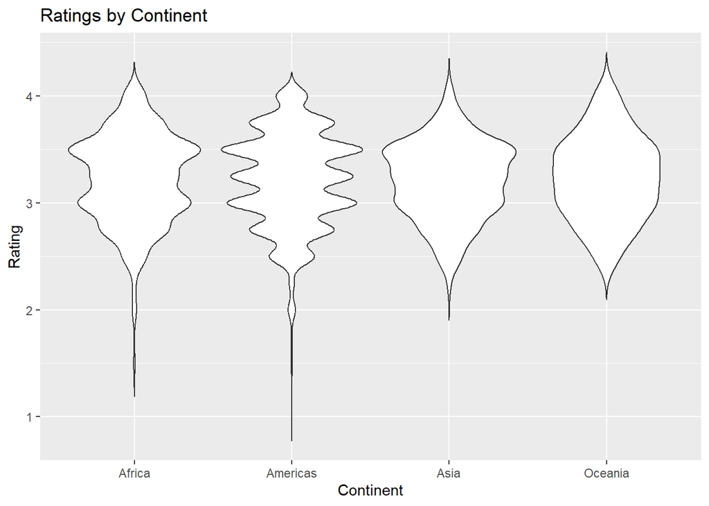

```r
ggplot(newchocol, aes(x = continent, y = rating)) +
  geom_violin(trim = FALSE) +
  labs(x = "Continent",
       y = "Rating",
       title = "Ratings by Continent")
```

## Part 3 Convert wide data into long data

We are going to create a set of features for us to plot over time. Use the functions in dplyr and tidyr to perform the following steps to the chocolate dataset:

1. Create a new set of columns titled beans, sugar, cocoa_butter, vanilla, letchin, and salt that contain a 1 or 0 representing whether or not that review for the chocolate bar contained that ingredient (1) or not (0).
2. Create a new set of columns titled char_cocoa, char_sweet, char_nutty, char_creamy, char_roasty, char_earthy that contain a 1 or 0 representing whether or not that the most memorable characteristic for the chocolate bar had that word (1) or not (0).

   For example, if the word “sweet” appears in the most_memorable_characteristics, then record a 1, otherwise a 0 for that review in the char_sweet column (Hint: check out str_detect() from the stringr package).
3. For each year (i.e. review_date), calculate the mean value in each new column you created across all reviews for that year. (Hint: If all has gone well thus far, you should have a dataset with 16 rows and 13 columns).
4. Convert this wide dataset into a long dataset with a new feature and mean_score column.

```r
library(stringr)
 chocolate_new <- chocolate %>%
  replace_na(list(ingredients = "")) %>%
  mutate(
    beans = ifelse(str_detect(ingredients, "B"), 1, 0),
    sugar = ifelse(str_detect(ingredients, "\\bS\\b") & !str_detect(ingredients, "S\\*"), 1, 0),
    cocoa_butter = ifelse(str_detect(ingredients, "C"), 1, 0),
    vanilla = ifelse(str_detect(ingredients, "V"), 1, 0),
    lecithin = ifelse(str_detect(ingredients, "L"), 1, 0),
    salt = ifelse(str_detect(ingredients, "Sa"), 1, 0)
  )

chocolate_new<- chocolate_new %>%
  mutate(
    char_cocoa = ifelse(str_detect(most_memorable_characteristics, "cocoa"), 1, 0),   # Cocoa
    char_sweet = ifelse(str_detect(most_memorable_characteristics, "sweet"), 1, 0),   # Sweet
    char_nutty = ifelse(str_detect(most_memorable_characteristics, "nutty"), 1, 0),   # Nutty
    char_creamy = ifelse(str_detect(most_memorable_characteristics, "creamy"), 1, 0), # Creamy
    char_roasty = ifelse(str_detect(most_memorable_characteristics, "roasty"), 1, 0), # Roasty
    char_earthy = ifelse(str_detect(most_memorable_characteristics, "earthy"), 1, 0)  # Earthy
  )

summary_new <- chocolate_new %>%dplyr::group_by(review_date)%>%
  summarise(
    mean_beans = mean(beans, na.rm = TRUE),
    mean_sugar = mean(sugar, na.rm = TRUE),
    mean_cocoa_butter = mean(cocoa_butter, na.rm = TRUE),
    mean_vanilla = mean(vanilla, na.rm = TRUE),
    mean_lecithin = mean(lecithin, na.rm = TRUE),
    mean_salt = mean(salt, na.rm = TRUE) ,
    mean_char_cocoa = mean(char_cocoa, na.rm = TRUE),
    mean_char_sweet = mean(char_sweet, na.rm = TRUE),
    mean_char_nutty = mean(char_nutty, na.rm = TRUE),
    mean_char_creamy = mean(char_creamy, na.rm = TRUE),
    mean_char_roasty = mean(char_roasty, na.rm = TRUE),
    mean_char_earthy = mean(char_earthy, na.rm = TRUE)
  )

summary_long<- summary_new %>%
  pivot_longer(
    cols = starts_with("mean_"),
    names_to = "feature_char",
    values_to = "mean_score"
  )

print(summary_long)
```

```
## # A tibble: 192 × 3
##    review_date feature_char      mean_score
##          <dbl> <chr>                  <dbl>
##  1        2006 mean_beans            0.968
##  2        2006 mean_sugar            0.968
##  3        2006 mean_cocoa_butter     0.903
##  4        2006 mean_vanilla          0.694
##  5        2006 mean_lecithin         0.694
##  6        2006 mean_salt             0
##  7        2006 mean_char_cocoa       0.210
##  8        2006 mean_char_sweet       0.161
##  9        2006 mean_char_nutty       0.0323
## 10        2006 mean_char_creamy      0.242
## # ℹ 182 more rows
```

## PART 4

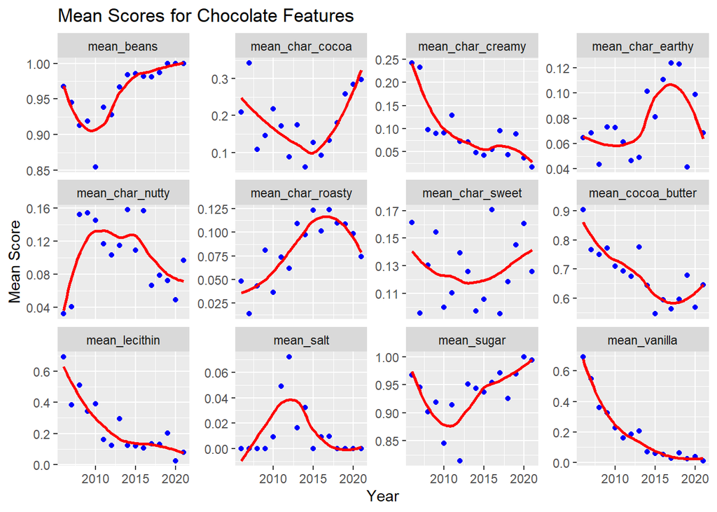

```r
ggplot(summary_long, aes(x = review_date, y = mean_score)) +
  geom_point(color = "blue") +                             # Observed points
  geom_smooth(method = "loess", se = FALSE, color = "red") + # Smoothed non-linear trend line
    facet_wrap(~ feature_char, scales = "free_y") +               # One plot for each feature
  labs(
    title = "Mean Scores for Chocolate Features",            # Overall title
    x = "Year",
    y = "Mean Score"
  )
```

## PART 5

Tasks

Using the chocolate dataset (or any of the modified versions you made throughout this assignment or anything else you wish you build upon it):

1. Make the absolute worst plot that you can. You need to customize it in at least 7 ways to make it awful.
2. In your document, write 1 - 2 sentences about each different customization you added (using bullets – i.e. there should be at least 7 bullet points each with 1-2 sentences), and how it could be useful for you when you want to make an awesome data visualization.

[output not shown]

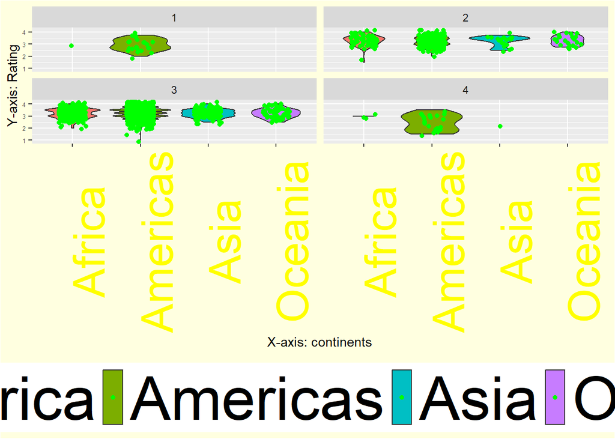

```r
newchocol$cocoa_num <- as.numeric(substr(newchocol$cocoa_percent, 1, nchar(newchocol$cocoa_percent)-1))
newchocol <- newchocol %>%
  dplyr::mutate(percgroup = case_when(
        cocoa_num < 60 ~ 1,
        cocoa_num >= 60 & cocoa_num <70 ~ 2,
        cocoa_num >= 70 & cocoa_num <90 ~ 3,
        cocoa_num >=90 ~ 4
    ))


newchocol %>%
  ggplot(aes(
        x = continent,
        y = rating,
        fill = continent

    )) +
    geom_violin()+
  facet_wrap(~as.factor(percgroup))+
  geom_jitter(width = 0.2, color = "green", height=0.2) +
  labs(
    x = "X-axis: continents",
    y = "Y-axis: Rating",
    fill = "No Legend"
  ) +
  theme(
    plot.background = element_rect(fill = "lightyellow"), #light color
    axis.text.x = element_text(angle = 90, size = 36, color = "yellow"), # Hard to read, rotated x-axis text
    axis.text.y = element_text(size = 5),
    legend.position = "bottom",                             # Clunky legend position
    legend.text = element_text(size = 50)                   # Overly large legend text
  )
```

## PART 6

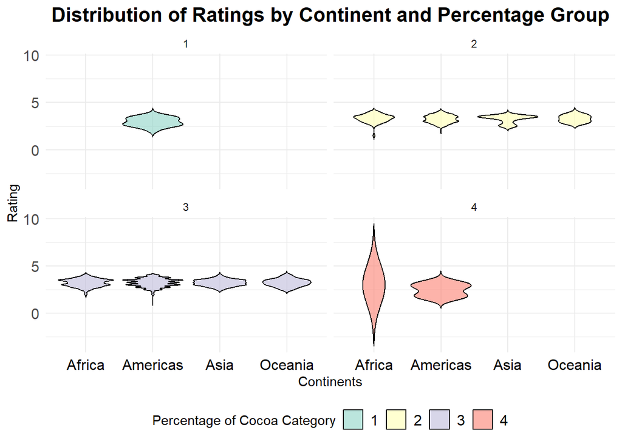

[output not shown]

```r
newchocol %>%
  ggplot(aes(
        x = continent,
        y = rating,
        fill = as.factor(percgroup)  # Fill based on percgroup, treat as factor
    )) +
    geom_violin(trim = FALSE, alpha = 0.6, color = "black") +   # Use alpha and black outline
    scale_fill_brewer(palette = "Set3") +                       # Use a color palette for better visuals
    facet_wrap(~as.factor(percgroup))+
    labs(
      title = "Distribution of Ratings by Continent and Percentage Group",  # Clear and informative title
      x = "Continents",                                                    # Improved x-axis label
      y = "Rating",                                                        # Improved y-axis label
      fill = "Percentage of Cocoa Category"                                           # Clarified legend lab
    ) +
    theme_minimal() +                                                      # Clean theme
    theme(
      plot.background = element_rect(fill = "white", color="white", linewidth = 1),
      axis.text.x = element_text(size = 12, color = "black"),
      axis.text.y = element_text(size = 12),
      legend.position = "bottom",
      legend.text = element_text(size = 12),
      plot.title = element_text(size = 16, face = "bold", hjust = 0.5)  # Centered and bold title
    )
```